# Statistical Distributions

## Probability Density Functions (PDF) and Probability Mass Functions (PMF)

**PMF**: A PMF is a function that gives the probability that a **discrete** random value is equal to a certain value. It is used to define a discrete probability distribution. If $X$ is a random variable defined on a sample space $S$ (ie $X$ can take its values in $S$), then the PMF is defined as : $$f_{X}(x) = P(X=x)$$

*As any probabilistic distribution, the sum of all probabilities is equal to 1, we therefore have $\sum f_{X}(x) = 1$*

**PDF**: A PDF, also called **"density"**, can be seen as the equivalent of a PDF for the case when the random variable is **continuous**. A random variable $X$ defined on a continuous support has a PDF $f_{x}$ if $P(a\leq X \leq b) = \int_{a}^{b}f_{X}(x)dx$. Once again, don't forget that if $X$ is defined on a support $S$ then $\int_{S}f_{X}(x)dx = 1$.

**Question**: We consider the distribution for the height (in cm) of a given population. Height, though often given without decimals, is a continuous variable. Assuming that the random variable $X$ representing the height of a individual follows a PDF given by $f_{X}(x)$. What is the probability that an individual has exactly a height $h$ ? **Answer**: 0. Indeed, we have $P(h\leq X \leq h) = \int_{h}^{h}f_{X}(x)dx = 0$

## Discrete distributions

Discrete distributions are used when the data takes discrete values, meaning that the sample space (the possible values that a phenomenon or an experiment can take) is discrete. An example of such sample space can be {tails, heads} for a coin tossing, the number given by a dice roll, etc.

```python
import matplotlib.pyplot as plt
import numpy as np
import seaborn as sns
import pandas as pd
import matplotlib
%matplotlib inline

size = 1000
plt.rcParams["figure.figsize"] =  [20, 5]
plt.style.use('fivethirtyeight')
print(matplotlib.__version__)
```

```
3.0.0
```

### Bernoulli Distribution (*Toss a coin: chances of success ?*)

The Bernoulli distribution is the simplest discrete distribution one can find. The sample space (ie the values our random variable can take) is $\{0, 1\}$, or $\{failure, success\}$. It gives the number of successes of an experiment. If the success probability is $p$, then the probability density function is given by : $$f(0) = 1 - p$$ $$f(1) = p$$ The mean and variance are given by : $$\mu = p$$ $$\sigma^2 = p(1 - p)$$

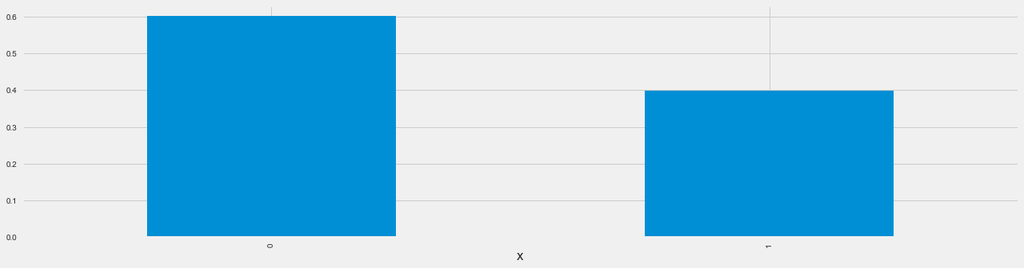

```python
from scipy.stats import bernoulli

p = 0.4
x = bernoulli.rvs(p=p, size=size)
df = pd.DataFrame({'x': x})
df = df.groupby('x')['x'].count()/size
df.plot(kind="bar")
```

### Binomial Distribution *(Toss several coins, how many successes ?)*

The Binomial distribution is a n-times repeated Bernoulli experiment. If we consider a Bernoulli experiment indenpendantly repeated n-times, with a sample space equal to {0, 1}, with a success probability of p and k successes, we get the following PMF: $$P(X=k)=\binom{n}{k}p^{k}(1-p)^{n-k}$$ $$Mean: \mu = np$$ $$Variance: \sigma^{2} = np(1 - p)$$

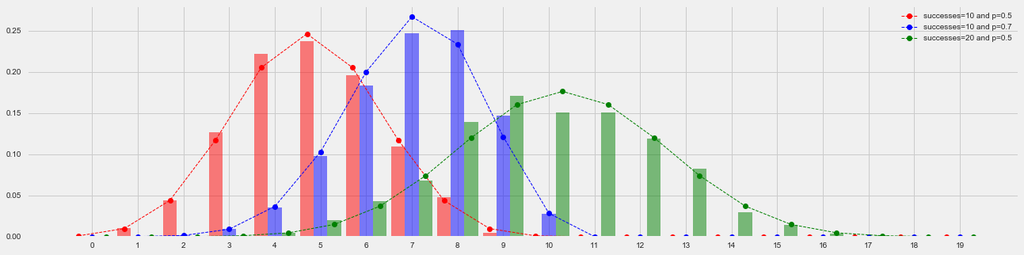

```python
from scipy.stats import binom

fig, ax = plt.subplots()
for p, n, c, offset in zip((0.5, 0.7, 0.5), (10, 10, 20), ('r','b','g'), (-1, 0, 1)):
    rvs = binom.rvs(n=n, p=p, size=size)
    hist, bins = np.histogram(rvs, bins=np.arange(0, 20))
    hist = hist / np.sum(hist)
    ax.bar(bins[:-1]+0.3*offset, height=hist, width=0.3, color=c, alpha=0.5)

    # x is the support
    x = np.arange(0, 20)
    y = binom.pmf(x, n=n, p=p)
    plt.plot(x+0.3*offset, y, 'o--', color=c, linewidth=1, label='successes='+str(n)+' and p='+str(p))
plt.xticks(np.arange(0,20))
plt.legend()
```

### Hypergeometric Distribution *(Binomial without replacement)*

The Hypergeometric distribution is very similar to the Binomial distribution except that it is used for a n-times repeated Bernoulli experiment **without replacement** . The parameters are $N$ the population size, $K$ the size of the population with particular feature, $k$ is the number of successful draws, $n$ is the number of trials : $$PMF : P(X=k)=\frac {\binom{K}{k} \binom{N-K}{n-k}}{\binom{N}{n}}$$ $$Mean: \mu = n\frac{K}{N}$$ $$Variance: \sigma^{2} = n\frac{K}{N}\frac{(N-K)}{N}\frac{(N-n)}{(N-1}$$

### Geometric Distribution *(How many failures before a success ?)*

The Geometric distribution models the number of trials before the first success for repeated independant Bernoulli experiments. Imagine tossing a coin and looking at the number k of trials before you get your first successful outcome:
$$PMF: P(X=k)=p(1-p)^{k-1}$$ $$Mean: \mu = \frac{1}{p}$$ $$Variance: \sigma^{2} = \frac{1}{1 - p^{2}}$$

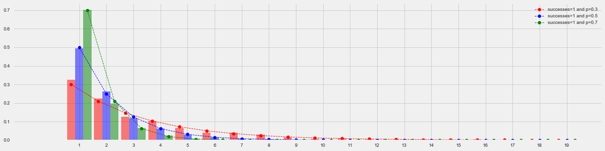

```python
from scipy.stats import geom

fig, ax = plt.subplots()
# p is the probability of a single Bernoulli trial success. Here, p=0.5
p=0.5
# n is the total successes to achieve before stopping the experiment
data = []
for p, c, offset in zip((0.3, 0.5, 0.7), ('r','b','g'), (-1, 0, 1)):
    # Generate random variable samples
    rvs = geom.rvs(p=p, size=size)
    hist, bins = np.histogram(rvs, bins=np.arange(0, 20))
    hist = hist / np.sum(hist)
    ax.bar(bins[:-1]+0.3*offset, height=hist, width=0.3, color=c, alpha=0.5)

    # x is the support
    x = np.arange(1, 20)
    y = geom.pmf(x, p=p)
    plt.plot(x+0.3*offset, y, 'o--', color=c, linewidth=1, label='successes='+str(n)+' and p='+str(p))
plt.xticks(np.arange(1,20))
plt.legend()
```

### Negative Binomial Distribution *(How many failures before k successes ?)*

The Negative binomial distribution is a generelization of the Geometric distribution. It describes a sequence of $n$ i.i.d. Bernoulli trials, but whereas the Geometric distribution modelled the number of trials before the first success, the Negative Binomial distribution models the numbers of repeated trials until a predefined number $k$ of successes has been reached. A Geometric distribution is therefore a Negative Binomial distribution with $k=1$.
The parameters are $p$ the success probability of a single Bernoulli trial, $k$ the number of failures, and $n$ the number of trials. We get the following PMF: $$P(X=k)=\binom{n+k-1}{k-1}p^{n}(1-p)^{k}$$ $$Mean: \mu = \frac{r}{p}$$ $$Variance: \sigma^{2} = \frac{rq}{1-p^2}$$

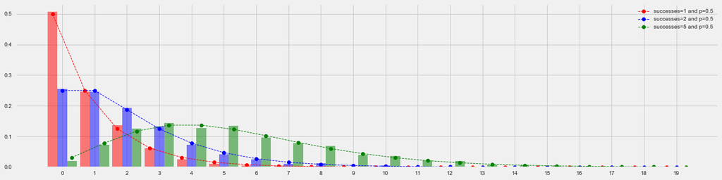

```python
from scipy.stats import nbinom

fig, ax = plt.subplots()
# p is the probability of a single Bernoulli trial success. Here, p=0.5
p=0.5
# n is the total successes to achieve before stopping the experiment
data = []
for n, c, offset in zip((1, 2, 5), ('r','b','g'), (-1, 0, 1)):
    # Generate random variable samples
    rvs = nbinom.rvs(n=n, p=p, size=size)
    hist, bins = np.histogram(rvs, bins=np.arange(0, 20))
    hist = hist / np.sum(hist)
    ax.bar(bins[:-1]+0.3*offset, height=hist, width=0.3, color=c, alpha=0.5)

    # x is the support
    x = np.arange(0, 20)
    y = nbinom.pmf(x, n=n, p=p)
    plt.plot(x+0.3*offset, y, 'o--', color=c, linewidth=1, label='successes='+str(n)+' and p='+str(p))
plt.xticks(np.arange(0,20))
plt.legend()
```

If you want to convince yourself about the above results, think about tossing a coin several times. We assume the coin is well balanced and therefore shows a probability $p$ of success equal to 0.5.

In red : what is the probability of having 0 failure before the first success ? Well it is simply the probability to get a success on the first trial, ie 0.5. That's the left-most red column and dot on the graph.

In blue : what is the probability of having 0 failure before 2 successes (ie what is the probability to get 2 successful trials on your 2 first tries ?) ? Assuming that the trials are i.i.d, let's denote $A$ the event "success on the first try" and $B$ "success on the second try". Given that $A$ and $B$ are independant, we get : $$P(A\cap B) = P(A)*P(B)$$ which gives us = 0.5 * 0.5 = 0.25

### Uniform Distribution *(Roll a fair dice)*

```
(0, 1)
```

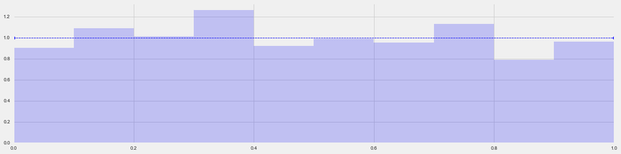

```python
from scipy.stats import uniform

fig, ax = plt.subplots()
# p is the probability of a single Bernoulli trial success. Here, p=0.5
p=0.5
# n is the total successes to achieve before stopping the experiment
data = []
    # Generate random variable samples
rvs = uniform.rvs(size=size)
ax.hist(rvs, density=True, histtype='stepfilled', alpha=0.2, color='b')

    # x is the support
y = uniform.pdf(x)
ax.plot(y, 'o--', color='b', linewidth=1)
ax.set_xlim(0, 1)
```

### Poisson Distribution *(How many events in a given time interval ?)*

The Poisson distribution is used to model the number of events occuring during a given time interval. You could think of the number of meteorites hitting the Earth during a 100-year period, the number of calls received on your mobile during a day, etc... The parameter $\lambda$ used in this distribution is the average number of events if the givent time interval. The characteristics of the Poisson distribution are given below: $$PMF: P(X=k)=e^{-\lambda}\frac{\lambda^{k}}{k!}$$ $$Mean: \mu = \lambda$$ $$Variance: \sigma^{2} = \lambda$$

$k$ is a Poisson random variable and the distribution of $k$ follows a Poisson distribution if the following criteria are met:

- $k$ takes values in $\mathbb{N}$
- the events are independant, meaning that the occurence of an event does not influence the occurence of following events
- the rate $\lambda$ is constant (in fact, it is calculated as an average of occuring events across time intervals)
- two events cannot occur simultaneously, ie you can find a time interval a small as you want between these two events

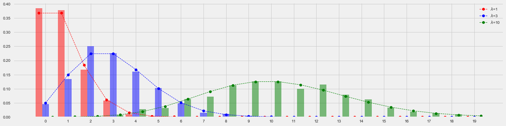

```python
from scipy.stats import poisson

fig, ax= plt.subplots()

for k, c, offset in zip([1, 3, 10], ('r','b','g'), (-1, 0, 1)):
    rvs = poisson.rvs(k, size=size)
    hist, bins = np.histogram(rvs, bins=np.arange(0, 20))
    hist = hist / np.sum(hist)
    ax.bar(bins[:-1]+0.3*offset, height=hist, width=0.3, color=c, alpha=0.5)

    # x is the support
    x = np.arange(0, 20)
    y =  poisson.pmf(x, mu=k)
    plt.plot(x+0.3*offset, y, 'o--', color=c, linewidth=1, label="$\lambda$="+str(k))
plt.xticks(np.arange(0,20))
plt.legend()
```

**Example**: We suppose that, over a period of 100 years, 1 meteorite hits the Earth on average. What is the probability that at least one meteorite will hit the Earth during the next 100 years ?

**Answer** : We take a random variable $X$ following a Poisson distribution to model the probabilities of the number of meteorites hitting the Earth in the next 100 years. $\lambda$ is equal to 1. We have $P(X=0)=e^{-\lambda}\frac{\lambda^{0}}{0!} = 0.368$.  
The probability of having at least a meteorite hitting the Earth during the next 100 years is therefore $1 - P(X=0) = 0.63$ (remember that $\sum{P(X=k)}=1$)

## Continuous Distributions

### Exponential Distribution *(How much time before an event ?)*

The Exponential distribution answers the question "How much time before an event". It is often used to compute the reliability of a component given its failure rate. The parameter $\lambda$ used in this distribution is the called the rate and reprensents the skewness of the distribution. The characteristics of the Exponential distribution are given below: $$PDF: f(x;k)=\lambda e^{-\lambda x}$$ $$Mean: \mu = \frac {1}{\lambda}$$ $$Variance: \sigma^{2} = \frac {1}{\lambda^{2}}$$

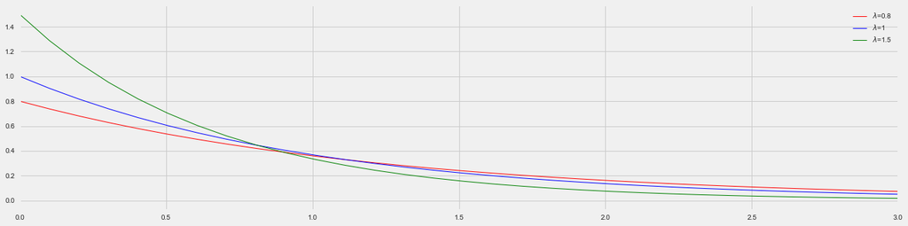

```python
from scipy.stats import expon

fig, ax = plt.subplots()
for l, c in zip((0.8, 1, 1.5),('r','b','g')):
    x = np.linspace(0, 10, 100)
    y =  expon.pdf(x, scale=1./l)
    plt.plot(x, y, '-', color=c, linewidth=1, label="$\lambda$="+str(l))
plt.xlim(0, 3)
plt.legend()
```

**Example**: You sell laptops and you want to know how to set the guarantee period.

- Question 1: You want to know how long it will take so that 50% of your stock (let's assume you sell all of your stock now) is still working ? You also know that your components usually fail after 2 years
- Question 2: What are the chances that a laptop bought now will still be working after 2 years ?

**Answer**:

```
k = 0.34657359027997264
0.9816843611112658
```

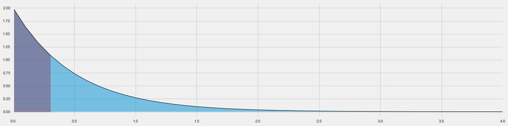

```python
dist = expon(scale=1./2)
print("k =", dist.ppf(0.5))
x = np.linspace(0, 10, 100)
y =  dist.pdf(x)
plt.plot(x, y, '-', color='k', linewidth=1, label="$\lambda$="+str(l))
plt.fill_between(x[x <= dist.ppf(0.5)], y[x <= dist.ppf(0.5)], 0, color='r', alpha=0.5)
plt.fill_between(x, y, 0, alpha=0.5)
plt.xlim(0, 4)

print(dist.cdf(2.))
```

### Uniform Distribution *(All equal)*

### Normal Distribution *(The mother of all distributions)*

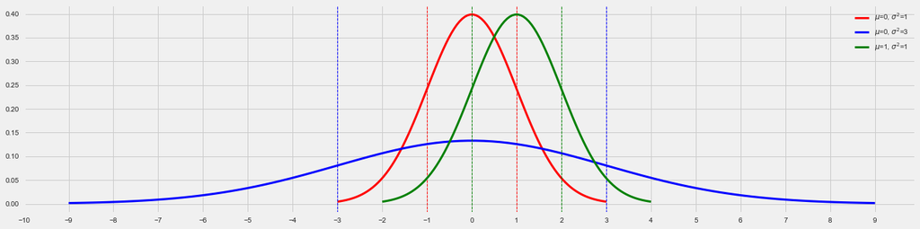

```python
from scipy.stats import norm

fig, ax= plt.subplots()

for mu, sigma, c, offset in zip([0, 0, 1], [1, 3, 1], ('r','b','g'), (-1, 0, 1)):
    rvs = norm.rvs(loc=mu, scale=sigma, size=size)
    hist, bins = np.histogram(rvs, bins=100)
    hist = hist / np.sum(hist)
    #ax.bar(bins[:-1]+0.3*offset, height=hist, width=0.3, color=c, alpha=0.5)

    # x is the support
    x = np.linspace(mu-3*sigma, mu+3*sigma, 100)
    y =  norm.pdf(x, loc=mu, scale=sigma)
    ax.plot(x, y, '-', color=c, linewidth=3, label="$\mu$="+str(mu)+", $\sigma^{2}$="+str(sigma))
    ax.axvline(mu-sigma, 0, 1, color=c, linestyle='--', linewidth=1)
    ax.axvline(mu+sigma, 0, 1, color=c, linestyle='--', linewidth=1)
plt.xticks(np.arange(-10, 10))
plt.legend()
```

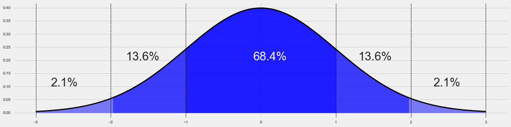

```python
fig, ax = plt.subplots()
c = 'k'
x = np.linspace(-3, 3, 100)
y =  norm.pdf(x, loc=0, scale=1)
ax.plot(x, y, '-', color=c, linewidth=3, label="$\mu$="+str(mu)+", $\sigma^{2}$="+str(sigma))
ax.axvline(-1, 0, 1, color=c, linestyle='--', linewidth=1)
ax.axvline(1, 0, 1, color=c, linestyle='--', linewidth=1)
ax.axvline(-2, 0, 1, color=c, linestyle='--', linewidth=1)
ax.axvline(2, 0, 1, color=c, linestyle='--', linewidth=1)
ax.axvline(-3, 0, 1, color=c, linestyle='--', linewidth=1)
ax.axvline(3, 0, 1, color=c, linestyle='--', linewidth=1)
plt.fill_between(x[np.abs(x)<=1], y[np.abs(x)<=1], 0, color='b', alpha=0.5)
plt.text(-.1, .2, '68.4%', fontsize=30, color='w')
plt.fill_between(x[np.abs(x)<=2], y[np.abs(x)<=2], 0, color='b', alpha=0.5)
plt.text(-1.8, .2, '13.6%', fontsize=30)
plt.text(1.3, .2, '13.6%', fontsize=30)
plt.fill_between(x[np.abs(x)<=3], y[np.abs(x)<=3], 0, color='b', alpha=0.5)
plt.text(-2.8, .1, '2.1%', fontsize=30)
plt.text(2.3, .1, '2.1%', fontsize=30)
```

### Chi-square ($\chi^{2}$) Distribution *(Sum of squares)*

Let's assume you are looking at $n$ variables, each with a mean and a variance such as $X_{i}~N(\mu, \sigma^{2})$. Each of these variables can be standardized to a normally distributed $Z$ random variable via the linear transform $Z_{i} = \frac {(X_{i} - \mu_{i})}{\sigma_{i}}$.  
With this, $Z^{2}$ follows a distribution which is called the Chi-square, or $\chi^{2}$, distribution. A Chi-square distibution has a number $n$ of degrees of freedom which corresponds to the number of random variables. Two Chi-square distributions of $m$ and $n$ degrees of freedom can be summed to yield a Chi-square distribution with $n+m$ degrees of freedom.